# Risk Factor Analysis

## Outcome Variable

**Outcome Variable:** ever_swasted

## Predictor Variables

**Intervention Variable:** birthlen

**Adjustment Set:**

- arm
- sex
- W_mage
- meducyrs
- feducyrs
- vagbrth
- single
- brthmon
- W_parity
- delta_W_mage
- delta_meducyrs
- delta_feducyrs
- delta_vagbrth
- delta_single
- delta_brthmon
- delta_W_parity

## Stratifying Variables

The analysis was stratified on these variable(s):

- agecat
- studyid
- country

## Data Summary

| agecat | studyid | country | birthlen | ever_swasted | n_cell | n |
| --- | --- | --- | --- | --- | --- | --- |
| 0-24 months (no birth wast) | ki0047075b-MAL-ED | BANGLADESH | >=50 cm | 0 | 36 | 229 |
| 0-24 months (no birth wast) | ki0047075b-MAL-ED | BANGLADESH | >=50 cm | 1 | 3 | 229 |
| 0-24 months (no birth wast) | ki0047075b-MAL-ED | BANGLADESH | <48 cm | 0 | 106 | 229 |
| 0-24 months (no birth wast) | ki0047075b-MAL-ED | BANGLADESH | <48 cm | 1 | 5 | 229 |
| 0-24 months (no birth wast) | ki0047075b-MAL-ED | BANGLADESH | [48-50) cm | 0 | 75 | 229 |
| 0-24 months (no birth wast) | ki0047075b-MAL-ED | BANGLADESH | [48-50) cm | 1 | 4 | 229 |
| 0-24 months (no birth wast) | ki0047075b-MAL-ED | BRAZIL | >=50 cm | 0 | 29 | 65 |
| 0-24 months (no birth wast) | ki0047075b-MAL-ED | BRAZIL | >=50 cm | 1 | 1 | 65 |
| 0-24 months (no birth wast) | ki0047075b-MAL-ED | BRAZIL | <48 cm | 0 | 17 | 65 |
| 0-24 months (no birth wast) | ki0047075b-MAL-ED | BRAZIL | <48 cm | 1 | 0 | 65 |
| 0-24 months (no birth wast) | ki0047075b-MAL-ED | BRAZIL | [48-50) cm | 0 | 18 | 65 |
| 0-24 months (no birth wast) | ki0047075b-MAL-ED | BRAZIL | [48-50) cm | 1 | 0 | 65 |
| 0-24 months (no birth wast) | ki0047075b-MAL-ED | INDIA | >=50 cm | 0 | 8 | 47 |
| 0-24 months (no birth wast) | ki0047075b-MAL-ED | INDIA | >=50 cm | 1 | 1 | 47 |
| 0-24 months (no birth wast) | ki0047075b-MAL-ED | INDIA | <48 cm | 0 | 19 | 47 |
| 0-24 months (no birth wast) | ki0047075b-MAL-ED | INDIA | <48 cm | 1 | 1 | 47 |
| 0-24 months (no birth wast) | ki0047075b-MAL-ED | INDIA | [48-50) cm | 0 | 16 | 47 |
| 0-24 months (no birth wast) | ki0047075b-MAL-ED | INDIA | [48-50) cm | 1 | 2 | 47 |
| 0-24 months (no birth wast) | ki0047075b-MAL-ED | NEPAL | >=50 cm | 0 | 8 | 27 |
| 0-24 months (no birth wast) | ki0047075b-MAL-ED | NEPAL | >=50 cm | 1 | 0 | 27 |
| 0-24 months (no birth wast) | ki0047075b-MAL-ED | NEPAL | <48 cm | 0 | 12 | 27 |
| 0-24 months (no birth wast) | ki0047075b-MAL-ED | NEPAL | <48 cm | 1 | 0 | 27 |
| 0-24 months (no birth wast) | ki0047075b-MAL-ED | NEPAL | [48-50) cm | 0 | 7 | 27 |
| 0-24 months (no birth wast) | ki0047075b-MAL-ED | NEPAL | [48-50) cm | 1 | 0 | 27 |
| 0-24 months (no birth wast) | ki0047075b-MAL-ED | PERU | >=50 cm | 0 | 51 | 233 |
| 0-24 months (no birth wast) | ki0047075b-MAL-ED | PERU | >=50 cm | 1 | 1 | 233 |
| 0-24 months (no birth wast) | ki0047075b-MAL-ED | PERU | <48 cm | 0 | 87 | 233 |
| 0-24 months (no birth wast) | ki0047075b-MAL-ED | PERU | <48 cm | 1 | 1 | 233 |
| 0-24 months (no birth wast) | ki0047075b-MAL-ED | PERU | [48-50) cm | 0 | 91 | 233 |
| 0-24 months (no birth wast) | ki0047075b-MAL-ED | PERU | [48-50) cm | 1 | 2 | 233 |

[output cut: 438 more lines]

The following strata were considered:

- agecat: 0-24 months (no birth wast), studyid: ki0047075b-MAL-ED, country: BANGLADESH
- agecat: 0-24 months (no birth wast), studyid: ki0047075b-MAL-ED, country: BRAZIL
- agecat: 0-24 months (no birth wast), studyid: ki0047075b-MAL-ED, country: INDIA
- agecat: 0-24 months (no birth wast), studyid: ki0047075b-MAL-ED, country: NEPAL
- agecat: 0-24 months (no birth wast), studyid: ki0047075b-MAL-ED, country: PERU
- agecat: 0-24 months (no birth wast), studyid: ki0047075b-MAL-ED, country: SOUTH AFRICA
- agecat: 0-24 months (no birth wast), studyid: ki0047075b-MAL-ED, country: TANZANIA, UNITED REPUBLIC OF
- agecat: 0-24 months (no birth wast), studyid: ki1000108-CMC-V-BCS-2002, country: INDIA
- agecat: 0-24 months (no birth wast), studyid: ki1000108-IRC, country: INDIA
- agecat: 0-24 months (no birth wast), studyid: ki1000109-EE, country: PAKISTAN
- agecat: 0-24 months (no birth wast), studyid: ki1000109-ResPak, country: PAKISTAN
- agecat: 0-24 months (no birth wast), studyid: ki1000304b-SAS-CompFeed, country: INDIA
- agecat: 0-24 months (no birth wast), studyid: ki1017093-NIH-Birth, country: BANGLADESH
- agecat: 0-24 months (no birth wast), studyid: ki1017093b-PROVIDE, country: BANGLADESH
- agecat: 0-24 months (no birth wast), studyid: ki1017093c-NIH-Crypto, country: BANGLADESH
- agecat: 0-24 months (no birth wast), studyid: ki1101329-Keneba, country: GAMBIA
- agecat: 0-24 months (no birth wast), studyid: ki1113344-GMS-Nepal, country: NEPAL
- agecat: 0-24 months (no birth wast), studyid: ki1114097-CMIN, country: BANGLADESH
- agecat: 0-24 months (no birth wast), studyid: ki1114097-CONTENT, country: PERU
- agecat: 0-24 months (no birth wast), studyid: ki1119695-PROBIT, country: BELARUS
- agecat: 0-24 months (no birth wast), studyid: ki1126311-ZVITAMBO, country: ZIMBABWE
- agecat: 0-24 months (no birth wast), studyid: ki1135781-COHORTS, country: GUATEMALA
- agecat: 0-24 months (no birth wast), studyid: ki1135781-COHORTS, country: INDIA
- agecat: 0-24 months (no birth wast), studyid: ki1135781-COHORTS, country: PHILIPPINES
- agecat: 0-24 months (no birth wast), studyid: kiGH5241-JiVitA-3, country: BANGLADESH
- agecat: 0-24 months (no birth wast), studyid: kiGH5241-JiVitA-4, country: BANGLADESH
- agecat: 0-6 months (no birth wast), studyid: ki0047075b-MAL-ED, country: BANGLADESH
- agecat: 0-6 months (no birth wast), studyid: ki0047075b-MAL-ED, country: BRAZIL
- agecat: 0-6 months (no birth wast), studyid: ki0047075b-MAL-ED, country: INDIA
- agecat: 0-6 months (no birth wast), studyid: ki0047075b-MAL-ED, country: NEPAL
- agecat: 0-6 months (no birth wast), studyid: ki0047075b-MAL-ED, country: PERU
- agecat: 0-6 months (no birth wast), studyid: ki0047075b-MAL-ED, country: SOUTH AFRICA
- agecat: 0-6 months (no birth wast), studyid: ki0047075b-MAL-ED, country: TANZANIA, UNITED REPUBLIC OF
- agecat: 0-6 months (no birth wast), studyid: ki1000108-CMC-V-BCS-2002, country: INDIA
- agecat: 0-6 months (no birth wast), studyid: ki1000108-IRC, country: INDIA
- agecat: 0-6 months (no birth wast), studyid: ki1000109-EE, country: PAKISTAN
- agecat: 0-6 months (no birth wast), studyid: ki1000109-ResPak, country: PAKISTAN
- agecat: 0-6 months (no birth wast), studyid: ki1000304b-SAS-CompFeed, country: INDIA
- agecat: 0-6 months (no birth wast), studyid: ki1017093-NIH-Birth, country: BANGLADESH
- agecat: 0-6 months (no birth wast), studyid: ki1017093b-PROVIDE, country: BANGLADESH
- agecat: 0-6 months (no birth wast), studyid: ki1017093c-NIH-Crypto, country: BANGLADESH
- agecat: 0-6 months (no birth wast), studyid: ki1101329-Keneba, country: GAMBIA
- agecat: 0-6 months (no birth wast), studyid: ki1113344-GMS-Nepal, country: NEPAL
- agecat: 0-6 months (no birth wast), studyid: ki1114097-CMIN, country: BANGLADESH
- agecat: 0-6 months (no birth wast), studyid: ki1114097-CONTENT, country: PERU
- agecat: 0-6 months (no birth wast), studyid: ki1119695-PROBIT, country: BELARUS
- agecat: 0-6 months (no birth wast), studyid: ki1126311-ZVITAMBO, country: ZIMBABWE
- agecat: 0-6 months (no birth wast), studyid: ki1135781-COHORTS, country: GUATEMALA
- agecat: 0-6 months (no birth wast), studyid: ki1135781-COHORTS, country: INDIA
- agecat: 0-6 months (no birth wast), studyid: ki1135781-COHORTS, country: PHILIPPINES
- agecat: 0-6 months (no birth wast), studyid: kiGH5241-JiVitA-3, country: BANGLADESH
- agecat: 0-6 months (no birth wast), studyid: kiGH5241-JiVitA-4, country: BANGLADESH
- agecat: 6-24 months, studyid: ki0047075b-MAL-ED, country: BANGLADESH
- agecat: 6-24 months, studyid: ki0047075b-MAL-ED, country: BRAZIL
- agecat: 6-24 months, studyid: ki0047075b-MAL-ED, country: INDIA
- agecat: 6-24 months, studyid: ki0047075b-MAL-ED, country: NEPAL
- agecat: 6-24 months, studyid: ki0047075b-MAL-ED, country: PERU
- agecat: 6-24 months, studyid: ki0047075b-MAL-ED, country: SOUTH AFRICA
- agecat: 6-24 months, studyid: ki0047075b-MAL-ED, country: TANZANIA, UNITED REPUBLIC OF
- agecat: 6-24 months, studyid: ki1000108-CMC-V-BCS-2002, country: INDIA
- agecat: 6-24 months, studyid: ki1000108-IRC, country: INDIA
- agecat: 6-24 months, studyid: ki1000109-EE, country: PAKISTAN
- agecat: 6-24 months, studyid: ki1000109-ResPak, country: PAKISTAN
- agecat: 6-24 months, studyid: ki1000304b-SAS-CompFeed, country: INDIA
- agecat: 6-24 months, studyid: ki1017093-NIH-Birth, country: BANGLADESH
- agecat: 6-24 months, studyid: ki1017093b-PROVIDE, country: BANGLADESH
- agecat: 6-24 months, studyid: ki1017093c-NIH-Crypto, country: BANGLADESH
- agecat: 6-24 months, studyid: ki1101329-Keneba, country: GAMBIA
- agecat: 6-24 months, studyid: ki1113344-GMS-Nepal, country: NEPAL
- agecat: 6-24 months, studyid: ki1114097-CMIN, country: BANGLADESH
- agecat: 6-24 months, studyid: ki1114097-CONTENT, country: PERU
- agecat: 6-24 months, studyid: ki1119695-PROBIT, country: BELARUS
- agecat: 6-24 months, studyid: ki1126311-ZVITAMBO, country: ZIMBABWE
- agecat: 6-24 months, studyid: ki1135781-COHORTS, country: GUATEMALA
- agecat: 6-24 months, studyid: ki1135781-COHORTS, country: INDIA
- agecat: 6-24 months, studyid: ki1135781-COHORTS, country: PHILIPPINES
- agecat: 6-24 months, studyid: kiGH5241-JiVitA-3, country: BANGLADESH
- agecat: 6-24 months, studyid: kiGH5241-JiVitA-4, country: BANGLADESH

### Dropped Strata

Some strata were dropped due to rare outcomes:

- agecat: 0-24 months (no birth wast), studyid: ki0047075b-MAL-ED, country: BANGLADESH
- agecat: 0-24 months (no birth wast), studyid: ki0047075b-MAL-ED, country: BRAZIL
- agecat: 0-24 months (no birth wast), studyid: ki0047075b-MAL-ED, country: INDIA
- agecat: 0-24 months (no birth wast), studyid: ki0047075b-MAL-ED, country: NEPAL
- agecat: 0-24 months (no birth wast), studyid: ki0047075b-MAL-ED, country: PERU
- agecat: 0-24 months (no birth wast), studyid: ki0047075b-MAL-ED, country: SOUTH AFRICA
- agecat: 0-24 months (no birth wast), studyid: ki0047075b-MAL-ED, country: TANZANIA, UNITED REPUBLIC OF
- agecat: 0-24 months (no birth wast), studyid: ki1000108-CMC-V-BCS-2002, country: INDIA
- agecat: 0-24 months (no birth wast), studyid: ki1000109-ResPak, country: PAKISTAN
- agecat: 0-24 months (no birth wast), studyid: ki1017093b-PROVIDE, country: BANGLADESH
- agecat: 0-24 months (no birth wast), studyid: ki1017093c-NIH-Crypto, country: BANGLADESH
- agecat: 0-24 months (no birth wast), studyid: ki1114097-CMIN, country: BANGLADESH
- agecat: 0-24 months (no birth wast), studyid: ki1114097-CONTENT, country: PERU
- agecat: 0-24 months (no birth wast), studyid: ki1119695-PROBIT, country: BELARUS
- agecat: 0-24 months (no birth wast), studyid: ki1135781-COHORTS, country: GUATEMALA
- agecat: 0-6 months (no birth wast), studyid: ki0047075b-MAL-ED, country: BANGLADESH
- agecat: 0-6 months (no birth wast), studyid: ki0047075b-MAL-ED, country: BRAZIL
- agecat: 0-6 months (no birth wast), studyid: ki0047075b-MAL-ED, country: INDIA
- agecat: 0-6 months (no birth wast), studyid: ki0047075b-MAL-ED, country: NEPAL
- agecat: 0-6 months (no birth wast), studyid: ki0047075b-MAL-ED, country: PERU
- agecat: 0-6 months (no birth wast), studyid: ki0047075b-MAL-ED, country: SOUTH AFRICA
- agecat: 0-6 months (no birth wast), studyid: ki0047075b-MAL-ED, country: TANZANIA, UNITED REPUBLIC OF
- agecat: 0-6 months (no birth wast), studyid: ki1000108-CMC-V-BCS-2002, country: INDIA
- agecat: 0-6 months (no birth wast), studyid: ki1000109-EE, country: PAKISTAN
- agecat: 0-6 months (no birth wast), studyid: ki1000109-ResPak, country: PAKISTAN
- agecat: 0-6 months (no birth wast), studyid: ki1000304b-SAS-CompFeed, country: INDIA
- agecat: 0-6 months (no birth wast), studyid: ki1017093-NIH-Birth, country: BANGLADESH
- agecat: 0-6 months (no birth wast), studyid: ki1017093b-PROVIDE, country: BANGLADESH
- agecat: 0-6 months (no birth wast), studyid: ki1017093c-NIH-Crypto, country: BANGLADESH
- agecat: 0-6 months (no birth wast), studyid: ki1113344-GMS-Nepal, country: NEPAL
- agecat: 0-6 months (no birth wast), studyid: ki1114097-CMIN, country: BANGLADESH
- agecat: 0-6 months (no birth wast), studyid: ki1114097-CONTENT, country: PERU
- agecat: 0-6 months (no birth wast), studyid: ki1119695-PROBIT, country: BELARUS
- agecat: 0-6 months (no birth wast), studyid: ki1135781-COHORTS, country: GUATEMALA
- agecat: 0-6 months (no birth wast), studyid: kiGH5241-JiVitA-4, country: BANGLADESH
- agecat: 6-24 months, studyid: ki0047075b-MAL-ED, country: BANGLADESH
- agecat: 6-24 months, studyid: ki0047075b-MAL-ED, country: BRAZIL
- agecat: 6-24 months, studyid: ki0047075b-MAL-ED, country: INDIA
- agecat: 6-24 months, studyid: ki0047075b-MAL-ED, country: NEPAL
- agecat: 6-24 months, studyid: ki0047075b-MAL-ED, country: PERU
- agecat: 6-24 months, studyid: ki0047075b-MAL-ED, country: SOUTH AFRICA
- agecat: 6-24 months, studyid: ki0047075b-MAL-ED, country: TANZANIA, UNITED REPUBLIC OF
- agecat: 6-24 months, studyid: ki1000108-CMC-V-BCS-2002, country: INDIA
- agecat: 6-24 months, studyid: ki1000109-EE, country: PAKISTAN
- agecat: 6-24 months, studyid: ki1000109-ResPak, country: PAKISTAN
- agecat: 6-24 months, studyid: ki1017093b-PROVIDE, country: BANGLADESH
- agecat: 6-24 months, studyid: ki1017093c-NIH-Crypto, country: BANGLADESH
- agecat: 6-24 months, studyid: ki1114097-CMIN, country: BANGLADESH
- agecat: 6-24 months, studyid: ki1114097-CONTENT, country: PERU
- agecat: 6-24 months, studyid: ki1119695-PROBIT, country: BELARUS
- agecat: 6-24 months, studyid: ki1135781-COHORTS, country: GUATEMALA

## Methods Detail

We’re interested in the causal parameters $E[Y_a]$ for all values of $a \in \mathcal{A}$. These parameters represent the mean outcome if, possibly contrary to fact, we intervened to set all units to have $A=a$. Under the randomization and positivity assumptions, these are identified by the statistical parameters $\psi_a=E_W[E_{Y|A,W}(Y|A=a,W)]$. In addition, we’re interested in the mean of $Y$, $E[Y]$ under no intervention (the observed mean). We will estimate these parameters by using SuperLearner to fit the relevant likelihood factors – $E_{Y|A,W}(Y|A=a,W)$ and $p(A=a|W)$, and then updating our likelihood fit using a joint TMLE.

For unadjusted analyses ($W=\{\}$), initial likelihoods were estimated using Lrnr_glm to estimate the simple $E(Y|A)$ and Lrnr_mean to estimate $p(A)$. For adjusted analyses, a small library containing Lrnr_glmnet, Lrnr_xgboost, and Lrnr_mean was used.

Having estimated these parameters, we will then use the delta method to estimate relative risks and attributable risks relative to a prespecified baseline level of $A$.

# Results Detail

## Results Plots

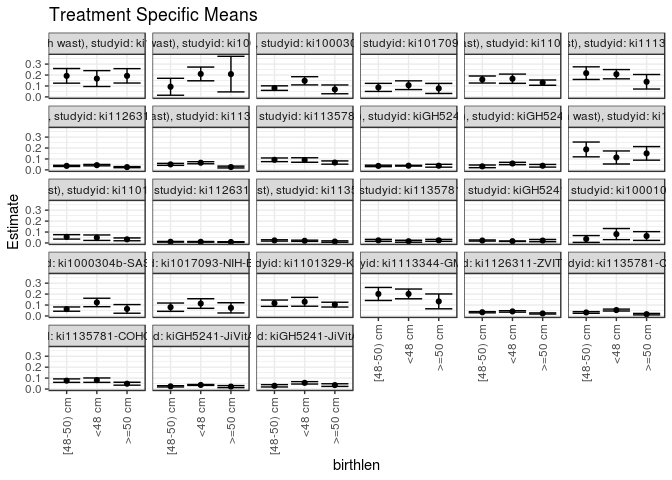

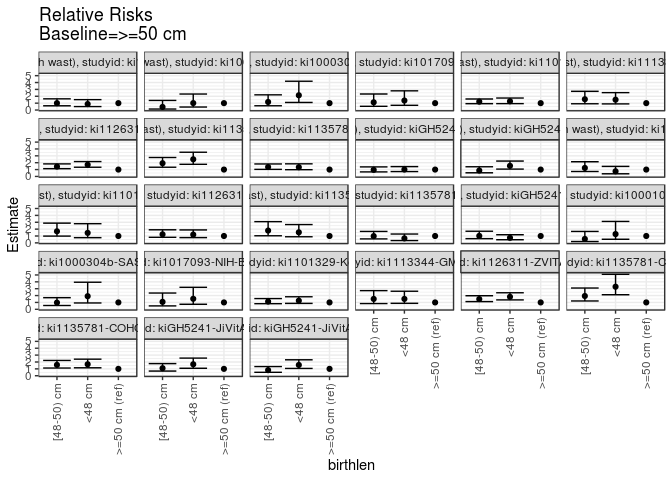

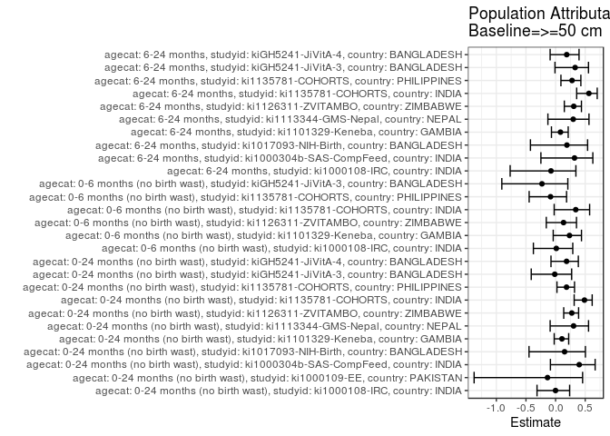

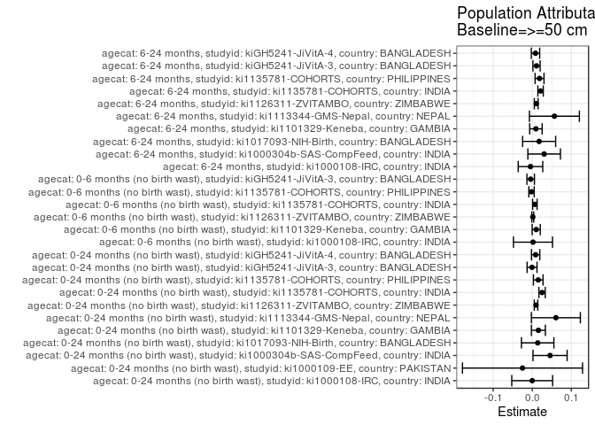

## Results Table

### Parameter: TSM

| agecat | studyid | country | intervention_level | baseline_level | estimate | ci_lower | ci_upper |
| --- | --- | --- | --- | --- | --- | --- | --- |
| 0-24 months (no birth wast) | ki1000108-IRC | INDIA | >=50 cm | NA | 0.1924698 | 0.1266313 | 0.2583083 |
| 0-24 months (no birth wast) | ki1000108-IRC | INDIA | <48 cm | NA | 0.1673905 | 0.0948642 | 0.2399167 |
| 0-24 months (no birth wast) | ki1000108-IRC | INDIA | [48-50) cm | NA | 0.1922769 | 0.1253173 | 0.2592364 |
| 0-24 months (no birth wast) | ki1000109-EE | PAKISTAN | >=50 cm | NA | 0.2083333 | 0.0455164 | 0.3711503 |
| 0-24 months (no birth wast) | ki1000109-EE | PAKISTAN | <48 cm | NA | 0.2098765 | 0.1470379 | 0.2727152 |
| 0-24 months (no birth wast) | ki1000109-EE | PAKISTAN | [48-50) cm | NA | 0.0925926 | 0.0151202 | 0.1700650 |
| 0-24 months (no birth wast) | ki1000304b-SAS-CompFeed | INDIA | >=50 cm | NA | 0.0685928 | 0.0283638 | 0.1088219 |
| 0-24 months (no birth wast) | ki1000304b-SAS-CompFeed | INDIA | <48 cm | NA | 0.1471442 | 0.1097575 | 0.1845309 |
| 0-24 months (no birth wast) | ki1000304b-SAS-CompFeed | INDIA | [48-50) cm | NA | 0.0802033 | 0.0592320 | 0.1011746 |
| 0-24 months (no birth wast) | ki1017093-NIH-Birth | BANGLADESH | >=50 cm | NA | 0.0773603 | 0.0313122 | 0.1234084 |
| 0-24 months (no birth wast) | ki1017093-NIH-Birth | BANGLADESH | <48 cm | NA | 0.1068828 | 0.0668158 | 0.1469497 |
| 0-24 months (no birth wast) | ki1017093-NIH-Birth | BANGLADESH | [48-50) cm | NA | 0.0867262 | 0.0498145 | 0.1236378 |
| 0-24 months (no birth wast) | ki1101329-Keneba | GAMBIA | >=50 cm | NA | 0.1304163 | 0.1063258 | 0.1545068 |
| 0-24 months (no birth wast) | ki1101329-Keneba | GAMBIA | <48 cm | NA | 0.1661351 | 0.1238506 | 0.2084196 |
| 0-24 months (no birth wast) | ki1101329-Keneba | GAMBIA | [48-50) cm | NA | 0.1587851 | 0.1265346 | 0.1910355 |
| 0-24 months (no birth wast) | ki1113344-GMS-Nepal | NEPAL | >=50 cm | NA | 0.1383347 | 0.0718702 | 0.2047992 |
| 0-24 months (no birth wast) | ki1113344-GMS-Nepal | NEPAL | <48 cm | NA | 0.2073762 | 0.1649032 | 0.2498492 |
| 0-24 months (no birth wast) | ki1113344-GMS-Nepal | NEPAL | [48-50) cm | NA | 0.2171471 | 0.1593905 | 0.2749036 |
| 0-24 months (no birth wast) | ki1126311-ZVITAMBO | ZIMBABWE | >=50 cm | NA | 0.0256059 | 0.0206291 | 0.0305827 |
| 0-24 months (no birth wast) | ki1126311-ZVITAMBO | ZIMBABWE | <48 cm | NA | 0.0435897 | 0.0373668 | 0.0498125 |
| 0-24 months (no birth wast) | ki1126311-ZVITAMBO | ZIMBABWE | [48-50) cm | NA | 0.0367967 | 0.0316183 | 0.0419751 |
| 0-24 months (no birth wast) | ki1135781-COHORTS | INDIA | >=50 cm | NA | 0.0263221 | 0.0181005 | 0.0345437 |
| 0-24 months (no birth wast) | ki1135781-COHORTS | INDIA | <48 cm | NA | 0.0657285 | 0.0562059 | 0.0752512 |
| 0-24 months (no birth wast) | ki1135781-COHORTS | INDIA | [48-50) cm | NA | 0.0506445 | 0.0416018 | 0.0596872 |
| 0-24 months (no birth wast) | ki1135781-COHORTS | PHILIPPINES | >=50 cm | NA | 0.0674202 | 0.0527052 | 0.0821353 |
| 0-24 months (no birth wast) | ki1135781-COHORTS | PHILIPPINES | <48 cm | NA | 0.0904471 | 0.0699322 | 0.1109620 |
| 0-24 months (no birth wast) | ki1135781-COHORTS | PHILIPPINES | [48-50) cm | NA | 0.0923804 | 0.0756206 | 0.1091401 |
| 0-24 months (no birth wast) | kiGH5241-JiVitA-3 | BANGLADESH | >=50 cm | NA | 0.0383248 | 0.0251676 | 0.0514820 |
| 0-24 months (no birth wast) | kiGH5241-JiVitA-3 | BANGLADESH | <48 cm | NA | 0.0385722 | 0.0352053 | 0.0419390 |
| 0-24 months (no birth wast) | kiGH5241-JiVitA-3 | BANGLADESH | [48-50) cm | NA | 0.0366492 | 0.0302402 | 0.0430582 |

[output cut: 51 more lines]

### Parameter: E(Y)

| agecat | studyid | country | intervention_level | baseline_level | estimate | ci_lower | ci_upper |
| --- | --- | --- | --- | --- | --- | --- | --- |
| 0-24 months (no birth wast) | ki1000108-IRC | INDIA | NA | NA | 0.1923077 | 0.1531430 | 0.2314724 |
| 0-24 months (no birth wast) | ki1000109-EE | PAKISTAN | NA | NA | 0.1833333 | 0.1342773 | 0.2323894 |
| 0-24 months (no birth wast) | ki1000304b-SAS-CompFeed | INDIA | NA | NA | 0.1141706 | 0.0903032 | 0.1380379 |
| 0-24 months (no birth wast) | ki1017093-NIH-Birth | BANGLADESH | NA | NA | 0.0912220 | 0.0677898 | 0.1146542 |
| 0-24 months (no birth wast) | ki1101329-Keneba | GAMBIA | NA | NA | 0.1460892 | 0.1284833 | 0.1636951 |
| 0-24 months (no birth wast) | ki1113344-GMS-Nepal | NEPAL | NA | NA | 0.1987860 | 0.1682929 | 0.2292792 |
| 0-24 months (no birth wast) | ki1126311-ZVITAMBO | ZIMBABWE | NA | NA | 0.0352566 | 0.0321456 | 0.0383677 |
| 0-24 months (no birth wast) | ki1135781-COHORTS | INDIA | NA | NA | 0.0514063 | 0.0459957 | 0.0568168 |
| 0-24 months (no birth wast) | ki1135781-COHORTS | PHILIPPINES | NA | NA | 0.0826968 | 0.0728574 | 0.0925361 |
| 0-24 months (no birth wast) | kiGH5241-JiVitA-3 | BANGLADESH | NA | NA | 0.0377996 | 0.0348944 | 0.0407048 |
| 0-24 months (no birth wast) | kiGH5241-JiVitA-4 | BANGLADESH | NA | NA | 0.0465950 | 0.0398949 | 0.0532951 |
| 0-6 months (no birth wast) | ki1000108-IRC | INDIA | NA | NA | 0.1532258 | 0.1165727 | 0.1898789 |
| 0-6 months (no birth wast) | ki1101329-Keneba | GAMBIA | NA | NA | 0.0430528 | 0.0328889 | 0.0532168 |
| 0-6 months (no birth wast) | ki1126311-ZVITAMBO | ZIMBABWE | NA | NA | 0.0099593 | 0.0082687 | 0.0116498 |
| 0-6 months (no birth wast) | ki1135781-COHORTS | INDIA | NA | NA | 0.0194977 | 0.0160139 | 0.0229815 |
| 0-6 months (no birth wast) | ki1135781-COHORTS | PHILIPPINES | NA | NA | 0.0220736 | 0.0168064 | 0.0273407 |
| 0-6 months (no birth wast) | kiGH5241-JiVitA-3 | BANGLADESH | NA | NA | 0.0177215 | 0.0156439 | 0.0197992 |
| 6-24 months | ki1000108-IRC | INDIA | NA | NA | 0.0588235 | 0.0354714 | 0.0821757 |
| 6-24 months | ki1000304b-SAS-CompFeed | INDIA | NA | NA | 0.0952035 | 0.0698704 | 0.1205365 |
| 6-24 months | ki1017093-NIH-Birth | BANGLADESH | NA | NA | 0.0919540 | 0.0671416 | 0.1167664 |
| 6-24 months | ki1101329-Keneba | GAMBIA | NA | NA | 0.1129792 | 0.0968836 | 0.1290747 |
| 6-24 months | ki1113344-GMS-Nepal | NEPAL | NA | NA | 0.1901528 | 0.1584343 | 0.2218713 |
| 6-24 months | ki1126311-ZVITAMBO | ZIMBABWE | NA | NA | 0.0331151 | 0.0297229 | 0.0365072 |
| 6-24 months | ki1135781-COHORTS | INDIA | NA | NA | 0.0377695 | 0.0330119 | 0.0425271 |
| 6-24 months | ki1135781-COHORTS | PHILIPPINES | NA | NA | 0.0670949 | 0.0578297 | 0.0763601 |
| 6-24 months | kiGH5241-JiVitA-3 | BANGLADESH | NA | NA | 0.0331237 | 0.0300503 | 0.0361971 |
| 6-24 months | kiGH5241-JiVitA-4 | BANGLADESH | NA | NA | 0.0442557 | 0.0375111 | 0.0510003 |

### Parameter: RR

| agecat | studyid | country | intervention_level | baseline_level | estimate | ci_lower | ci_upper |
| --- | --- | --- | --- | --- | --- | --- | --- |
| 0-24 months (no birth wast) | ki1000108-IRC | INDIA | >=50 cm | >=50 cm | 1.0000000 | 1.0000000 | 1.000000 |
| 0-24 months (no birth wast) | ki1000108-IRC | INDIA | <48 cm | >=50 cm | 0.8696972 | 0.5011327 | 1.509327 |
| 0-24 months (no birth wast) | ki1000108-IRC | INDIA | [48-50) cm | >=50 cm | 0.9989975 | 0.6126751 | 1.628916 |
| 0-24 months (no birth wast) | ki1000109-EE | PAKISTAN | >=50 cm | >=50 cm | 1.0000000 | 1.0000000 | 1.000000 |
| 0-24 months (no birth wast) | ki1000109-EE | PAKISTAN | <48 cm | >=50 cm | 1.0074074 | 0.4362537 | 2.326329 |
| 0-24 months (no birth wast) | ki1000109-EE | PAKISTAN | [48-50) cm | >=50 cm | 0.4444445 | 0.1414439 | 1.396532 |
| 0-24 months (no birth wast) | ki1000304b-SAS-CompFeed | INDIA | >=50 cm | >=50 cm | 1.0000000 | 1.0000000 | 1.000000 |
| 0-24 months (no birth wast) | ki1000304b-SAS-CompFeed | INDIA | <48 cm | >=50 cm | 2.1451830 | 1.0986057 | 4.188773 |
| 0-24 months (no birth wast) | ki1000304b-SAS-CompFeed | INDIA | [48-50) cm | >=50 cm | 1.1692657 | 0.6196455 | 2.206394 |
| 0-24 months (no birth wast) | ki1017093-NIH-Birth | BANGLADESH | >=50 cm | >=50 cm | 1.0000000 | 1.0000000 | 1.000000 |
| 0-24 months (no birth wast) | ki1017093-NIH-Birth | BANGLADESH | <48 cm | >=50 cm | 1.3816229 | 0.6834316 | 2.793084 |
| 0-24 months (no birth wast) | ki1017093-NIH-Birth | BANGLADESH | [48-50) cm | >=50 cm | 1.1210677 | 0.5392440 | 2.330657 |
| 0-24 months (no birth wast) | ki1101329-Keneba | GAMBIA | >=50 cm | >=50 cm | 1.0000000 | 1.0000000 | 1.000000 |
| 0-24 months (no birth wast) | ki1101329-Keneba | GAMBIA | <48 cm | >=50 cm | 1.2738831 | 0.9309751 | 1.743095 |
| 0-24 months (no birth wast) | ki1101329-Keneba | GAMBIA | [48-50) cm | >=50 cm | 1.2175249 | 0.9253781 | 1.601904 |
| 0-24 months (no birth wast) | ki1113344-GMS-Nepal | NEPAL | >=50 cm | >=50 cm | 1.0000000 | 1.0000000 | 1.000000 |
| 0-24 months (no birth wast) | ki1113344-GMS-Nepal | NEPAL | <48 cm | >=50 cm | 1.4990902 | 0.8895103 | 2.526414 |
| 0-24 months (no birth wast) | ki1113344-GMS-Nepal | NEPAL | [48-50) cm | >=50 cm | 1.5697222 | 0.9063894 | 2.718509 |
| 0-24 months (no birth wast) | ki1126311-ZVITAMBO | ZIMBABWE | >=50 cm | >=50 cm | 1.0000000 | 1.0000000 | 1.000000 |
| 0-24 months (no birth wast) | ki1126311-ZVITAMBO | ZIMBABWE | <48 cm | >=50 cm | 1.7023299 | 1.3375201 | 2.166642 |
| 0-24 months (no birth wast) | ki1126311-ZVITAMBO | ZIMBABWE | [48-50) cm | >=50 cm | 1.4370401 | 1.1304105 | 1.826845 |
| 0-24 months (no birth wast) | ki1135781-COHORTS | INDIA | >=50 cm | >=50 cm | 1.0000000 | 1.0000000 | 1.000000 |
| 0-24 months (no birth wast) | ki1135781-COHORTS | INDIA | <48 cm | >=50 cm | 2.4970868 | 1.7698947 | 3.523059 |
| 0-24 months (no birth wast) | ki1135781-COHORTS | INDIA | [48-50) cm | >=50 cm | 1.9240307 | 1.3428559 | 2.756732 |
| 0-24 months (no birth wast) | ki1135781-COHORTS | PHILIPPINES | >=50 cm | >=50 cm | 1.0000000 | 1.0000000 | 1.000000 |
| 0-24 months (no birth wast) | ki1135781-COHORTS | PHILIPPINES | <48 cm | >=50 cm | 1.3415419 | 0.9795312 | 1.837343 |
| 0-24 months (no birth wast) | ki1135781-COHORTS | PHILIPPINES | [48-50) cm | >=50 cm | 1.3702167 | 1.0320192 | 1.819243 |
| 0-24 months (no birth wast) | kiGH5241-JiVitA-3 | BANGLADESH | >=50 cm | >=50 cm | 1.0000000 | 1.0000000 | 1.000000 |
| 0-24 months (no birth wast) | kiGH5241-JiVitA-3 | BANGLADESH | <48 cm | >=50 cm | 1.0064546 | 0.7076872 | 1.431354 |
| 0-24 months (no birth wast) | kiGH5241-JiVitA-3 | BANGLADESH | [48-50) cm | >=50 cm | 0.9562791 | 0.6580512 | 1.389663 |

[output cut: 51 more lines]

### Parameter: PAR

| agecat | studyid | country | intervention_level | baseline_level | estimate | ci_lower | ci_upper |
| --- | --- | --- | --- | --- | --- | --- | --- |
| 0-24 months (no birth wast) | ki1000108-IRC | INDIA | >=50 cm | NA | -0.0001621 | -0.0524568 | 0.0521325 |
| 0-24 months (no birth wast) | ki1000109-EE | PAKISTAN | >=50 cm | NA | -0.0250000 | -0.1786684 | 0.1286684 |
| 0-24 months (no birth wast) | ki1000304b-SAS-CompFeed | INDIA | >=50 cm | NA | 0.0455777 | 0.0019169 | 0.0892386 |
| 0-24 months (no birth wast) | ki1017093-NIH-Birth | BANGLADESH | >=50 cm | NA | 0.0138617 | -0.0276719 | 0.0553953 |
| 0-24 months (no birth wast) | ki1101329-Keneba | GAMBIA | >=50 cm | NA | 0.0156729 | -0.0021899 | 0.0335358 |
| 0-24 months (no birth wast) | ki1113344-GMS-Nepal | NEPAL | >=50 cm | NA | 0.0604513 | -0.0022291 | 0.1231318 |
| 0-24 months (no birth wast) | ki1126311-ZVITAMBO | ZIMBABWE | >=50 cm | NA | 0.0096508 | 0.0051711 | 0.0141304 |
| 0-24 months (no birth wast) | ki1135781-COHORTS | INDIA | >=50 cm | NA | 0.0250842 | 0.0169745 | 0.0331938 |
| 0-24 months (no birth wast) | ki1135781-COHORTS | PHILIPPINES | >=50 cm | NA | 0.0152765 | 0.0029935 | 0.0275596 |
| 0-24 months (no birth wast) | kiGH5241-JiVitA-3 | BANGLADESH | >=50 cm | NA | -0.0005252 | -0.0131957 | 0.0121453 |
| 0-24 months (no birth wast) | kiGH5241-JiVitA-4 | BANGLADESH | >=50 cm | NA | 0.0086377 | -0.0020217 | 0.0192971 |
| 0-6 months (no birth wast) | ki1000108-IRC | INDIA | >=50 cm | NA | 0.0018735 | -0.0481387 | 0.0518856 |
| 0-6 months (no birth wast) | ki1101329-Keneba | GAMBIA | >=50 cm | NA | 0.0101159 | -0.0002348 | 0.0204666 |
| 0-6 months (no birth wast) | ki1126311-ZVITAMBO | ZIMBABWE | >=50 cm | NA | 0.0013414 | -0.0011725 | 0.0038552 |
| 0-6 months (no birth wast) | ki1135781-COHORTS | INDIA | >=50 cm | NA | 0.0066334 | 0.0008643 | 0.0124026 |
| 0-6 months (no birth wast) | ki1135781-COHORTS | PHILIPPINES | >=50 cm | NA | -0.0018813 | -0.0087726 | 0.0050099 |
| 0-6 months (no birth wast) | kiGH5241-JiVitA-3 | BANGLADESH | >=50 cm | NA | -0.0040761 | -0.0136985 | 0.0055462 |
| 6-24 months | ki1000108-IRC | INDIA | >=50 cm | NA | -0.0045568 | -0.0359562 | 0.0268427 |
| 6-24 months | ki1000304b-SAS-CompFeed | INDIA | >=50 cm | NA | 0.0304167 | -0.0112531 | 0.0720865 |
| 6-24 months | ki1017093-NIH-Birth | BANGLADESH | >=50 cm | NA | 0.0175739 | -0.0247385 | 0.0598862 |
| 6-24 months | ki1101329-Keneba | GAMBIA | >=50 cm | NA | 0.0093239 | -0.0066229 | 0.0252707 |
| 6-24 months | ki1113344-GMS-Nepal | NEPAL | >=50 cm | NA | 0.0566900 | -0.0072787 | 0.1206587 |
| 6-24 months | ki1126311-ZVITAMBO | ZIMBABWE | >=50 cm | NA | 0.0101634 | 0.0053062 | 0.0150207 |
| 6-24 months | ki1135781-COHORTS | INDIA | >=50 cm | NA | 0.0212493 | 0.0143461 | 0.0281524 |
| 6-24 months | ki1135781-COHORTS | PHILIPPINES | >=50 cm | NA | 0.0186498 | 0.0072218 | 0.0300779 |
| 6-24 months | kiGH5241-JiVitA-3 | BANGLADESH | >=50 cm | NA | 0.0109295 | 0.0017069 | 0.0201521 |
| 6-24 months | kiGH5241-JiVitA-4 | BANGLADESH | >=50 cm | NA | 0.0083090 | -0.0024087 | 0.0190268 |

### Parameter: PAF

| agecat | studyid | country | intervention_level | baseline_level | estimate | ci_lower | ci_upper |
| --- | --- | --- | --- | --- | --- | --- | --- |
| 0-24 months (no birth wast) | ki1000108-IRC | INDIA | >=50 cm | NA | -0.0008430 | -0.3133000 | 0.2372750 |
| 0-24 months (no birth wast) | ki1000109-EE | PAKISTAN | >=50 cm | NA | -0.1363636 | -1.3752423 | 0.4563408 |
| 0-24 months (no birth wast) | ki1000304b-SAS-CompFeed | INDIA | >=50 cm | NA | 0.3992074 | -0.0871215 | 0.6679748 |
| 0-24 months (no birth wast) | ki1017093-NIH-Birth | BANGLADESH | >=50 cm | NA | 0.1519558 | -0.4483118 | 0.5034364 |
| 0-24 months (no birth wast) | ki1101329-Keneba | GAMBIA | >=50 cm | NA | 0.1072832 | -0.0233955 | 0.2212754 |
| 0-24 months (no birth wast) | ki1113344-GMS-Nepal | NEPAL | >=50 cm | NA | 0.3041025 | -0.0917351 | 0.5564187 |
| 0-24 months (no birth wast) | ki1126311-ZVITAMBO | ZIMBABWE | >=50 cm | NA | 0.2737286 | 0.1372971 | 0.3885842 |
| 0-24 months (no birth wast) | ki1135781-COHORTS | INDIA | >=50 cm | NA | 0.4879594 | 0.3138696 | 0.6178779 |
| 0-24 months (no birth wast) | ki1135781-COHORTS | PHILIPPINES | >=50 cm | NA | 0.1847295 | 0.0232602 | 0.3195055 |
| 0-24 months (no birth wast) | kiGH5241-JiVitA-3 | BANGLADESH | >=50 cm | NA | -0.0138948 | -0.4110724 | 0.2714884 |
| 0-24 months (no birth wast) | kiGH5241-JiVitA-4 | BANGLADESH | >=50 cm | NA | 0.1853776 | -0.0774865 | 0.3841133 |
| 0-6 months (no birth wast) | ki1000108-IRC | INDIA | >=50 cm | NA | 0.0122269 | -0.3745773 | 0.2901849 |
| 0-6 months (no birth wast) | ki1101329-Keneba | GAMBIA | >=50 cm | NA | 0.2349652 | -0.0399723 | 0.4372174 |
| 0-6 months (no birth wast) | ki1126311-ZVITAMBO | ZIMBABWE | >=50 cm | NA | 0.1346873 | -0.1571834 | 0.3529409 |
| 0-6 months (no birth wast) | ki1135781-COHORTS | INDIA | >=50 cm | NA | 0.3402172 | -0.0238060 | 0.5748088 |
| 0-6 months (no birth wast) | ki1135781-COHORTS | PHILIPPINES | >=50 cm | NA | -0.0852293 | -0.4461338 | 0.1856060 |
| 0-6 months (no birth wast) | kiGH5241-JiVitA-3 | BANGLADESH | >=50 cm | NA | -0.2300099 | -0.9076269 | 0.2069076 |
| 6-24 months | ki1000108-IRC | INDIA | >=50 cm | NA | -0.0774648 | -0.7670506 | 0.3430124 |
| 6-24 months | ki1000304b-SAS-CompFeed | INDIA | >=50 cm | NA | 0.3194913 | -0.2478521 | 0.6288886 |
| 6-24 months | ki1017093-NIH-Birth | BANGLADESH | >=50 cm | NA | 0.1911157 | -0.4244304 | 0.5406628 |
| 6-24 months | ki1101329-Keneba | GAMBIA | >=50 cm | NA | 0.0825272 | -0.0697704 | 0.2131431 |
| 6-24 months | ki1113344-GMS-Nepal | NEPAL | >=50 cm | NA | 0.2981289 | -0.1296158 | 0.5639021 |
| 6-24 months | ki1126311-ZVITAMBO | ZIMBABWE | >=50 cm | NA | 0.3069119 | 0.1474276 | 0.4365627 |
| 6-24 months | ki1135781-COHORTS | INDIA | >=50 cm | NA | 0.5626044 | 0.3562024 | 0.7028338 |
| 6-24 months | ki1135781-COHORTS | PHILIPPINES | >=50 cm | NA | 0.2779618 | 0.0902659 | 0.4269324 |
| 6-24 months | kiGH5241-JiVitA-3 | BANGLADESH | >=50 cm | NA | 0.3299601 | -0.0100792 | 0.5555264 |
| 6-24 months | kiGH5241-JiVitA-4 | BANGLADESH | >=50 cm | NA | 0.1877510 | -0.0921193 | 0.3959007 |